# Machine Learnig Assignament

Rodrigo Gomez-Fell

22 de julio de 2015

# Overview

In this assignament the goal was to predict how a particular excercise was performed. In order to predict such outcome there where a data frame given, with different meassures of the exercise done by 6 young health participants, where they performed once accuratly (qualityt meassure), and four times with different movement errors (execution mistakes). The classification of the movement where under a variable named “Classe”, more info about the project data in http://groupware.les.inf.puc-rio.br/har.

The idea of fitting a good performing model was accomplished, a Generalized Boosted nmodel (GBM) was finally selected after a few previous approaches. More info on the gbm package in http://www.saedsayad.com/docs/gbm2.pdf and http://www.inside-r.org/packages/cran/gbm/docs/gbm

# Model Building

The data was presented in two separate data set one called pml-training.csv and a pml-testing.csv, we only used the training and then the test set was used only to submmit the results.

```r
fileUrl.train <- "https://d396qusza40orc.cloudfront.net/predmachlearn/pml-training.csv"
fileUrl.test <- "https://d396qusza40orc.cloudfront.net/predmachlearn/pml-testing.csv"

train <- read.csv(fileUrl.train, na.strings=c("NA", "", "#DIV/0!"))
test <- read.csv(fileUrl.test, na.strings=c("NA", "", "#DIV/0!"))
```

## Testing and Training sets (CrossValidation)

In the final model a data partition was used, that saved 40% of the data for testing when the final model is tune and 60% of the data for training. The caret package was used during the whole modelling process.

```r
library(caret)
set.seed(1001)
trainIndex <- createDataPartition(train$classe, p = 0.60,list=FALSE)
```

Before the data partition was made, columns 1 to 7 where left out given that they where eitherid tags, time of the sample or other non predictive value.

Then NA where taken on account, and all columns that had more than 50% of NA where left out (idea and code taken from discussion forums in Coursera).

Finally the model split

```r
train.df <- train[,8:160]
na.train <- train.df[, colSums(is.na(train.df)) < nrow(train.df) * 0.5]

training <- na.train[trainIndex,]
testing <- na.train[-trainIndex,]
```

## Choosing Features

The first step in choosing the variables was check which predictors contributed very little to the model. We used the nearZeroVar function.

```r
nzv.training <- nearZeroVar(training[-53], saveMetrics = T)
```

It didnt gave much information, all the predictors had enough variance to be used in our model.

```r
descrCor <- cor(training[,-53], use="pairwise.complete.obs", method="pearson")
summary(descrCor[upper.tri(descrCor)])
```

```
##      Min.   1st Qu.    Median      Mean   3rd Qu.      Max.
## -0.992100 -0.118100  0.005245  0.002501  0.106000  0.981200
```

## Preprocessing of the data

```r
preProc <- preProcess(training[,-53],method='BoxCox', verbose=FALSE)
trainPC <- predict(preProc, training[,-53])
```

## How the model was built

Knowing that was a classification problem, all models used for regression where left aside, and the search was focus only on classification models.

First choice was a bagged model (‘Adabag’), it didn’t gave the expected results. So a different kind of algorithm was looked for, one that could automaticly choose its own features.

Another dessition we took was use models that will choose predictors and had some sort of inner cross validation, beside the first splitting of the data.

## Choosing the model

### Adabag (Bagged Adaboost) Confussion Matrix

Estimated Error’ of this model based on the cross-validation with the Test subset is represented by (1- Overall Accuracy) shown in the resuls of the Confusion Matrix below (0.4322):

```
## Confusion Matrix and Statistics
##
##           Reference
## Prediction    A    B    C    D    E
##          A 2198   34    0    0    0
##          B  981  537    0    0    0
##          C 1324   44    0    0    0
##          D 1042  244    0    0    0
##          E  593  193    0    0  656
##
## Overall Statistics
##
##                Accuracy : 0.4322
##                  95% CI : (0.4212, 0.4432)
##     No Information Rate : 0.7823
##     P-Value [Acc > NIR] : 1
##
##                   Kappa : 0.2287
##  Mcnemar's Test P-Value : NA
##
## Statistics by Class:
##
##                      Class: A Class: B Class: C Class: D Class: E
## Sensitivity            0.3581  0.51046       NA       NA  1.00000
## Specificity            0.9801  0.85561   0.8256   0.8361  0.89068
## Pos Pred Value         0.9848  0.35375       NA       NA  0.45492
## Neg Pred Value         0.2982  0.91862       NA       NA  1.00000
## Prevalence             0.7823  0.13408   0.0000   0.0000  0.08361
## Detection Rate         0.2801  0.06844   0.0000   0.0000  0.08361
## Detection Prevalence   0.2845  0.19347   0.1744   0.1639  0.18379
## Balanced Accuracy      0.6691  0.68303       NA       NA  0.94534
```

### GBM model (Stochastic Gradient Boosting )

Expected ‘Out of Sample Error’ of this model with a depth of three levels would be (1 - 0.953), shown in the resampling results (0.0467196).

```r
gbm.model <- train(training$classe ~., method = 'gbm', data=trainPC, verbose=FALSE)
```

```
## Stochastic Gradient Boosting
##
## 11776 samples
##    51 predictor
##     5 classes: 'A', 'B', 'C', 'D', 'E'
##
## No pre-processing
## Resampling: Bootstrapped (25 reps)
##
## Summary of sample sizes: 11776, 11776, 11776, 11776, 11776, 11776, ...
##
## Resampling results across tuning parameters:
##
##   interaction.depth  n.trees  Accuracy   Kappa      Accuracy SD
##   1                   50      0.7444239  0.6760648  0.009521682
##   1                  100      0.8143803  0.7650960  0.006611622
##   1                  150      0.8476410  0.8072401  0.004985691
##   2                   50      0.8491514  0.8088991  0.006025559
##   2                  100      0.9014572  0.8752917  0.004720981
##   2                  150      0.9253412  0.9055308  0.004408303
##   3                   50      0.8932700  0.8648831  0.004811274
##   3                  100      0.9343848  0.9169624  0.003939415
##   3                  150      0.9532804  0.9408815  0.003076246
##   Kappa SD
##   0.012196126
##   0.008338129
##   0.006267702
##   0.007497363
##   0.005931508
##   0.005540049
##   0.006049072
##   0.004950896
##   0.003878772
##
## Tuning parameter 'shrinkage' was held constant at a value of 0.1
##
## Tuning parameter 'n.minobsinnode' was held constant at a value of 10
## Accuracy was used to select the optimal model using  the largest value.
## The final values used for the model were n.trees = 150,
##  interaction.depth = 3, shrinkage = 0.1 and n.minobsinnode = 10.
```

In figures 2 and 3 of the appendix the accuracy level is shown and a heat map of kappa bootstraping for each tree level.

Estimated Error of this model based on the cross-validation with the Test subset is represented by (1 - Accuracy) shown in the resuls of the Confusion Matrix below (0.0391):

```r
testPC <- predict(preProc, testing[,-53])
gbm.out <- confusionMatrix(testing$classe, predict(gbm.model, testPC))
gbm.out
```

```
## Confusion Matrix and Statistics
##
##           Reference
## Prediction    A    B    C    D    E
##          A 2201   24    2    3    2
##          B   52 1412   50    3    1
##          C    0   37 1307   21    3
##          D    0    2   37 1241    6
##          E    2   24   10   28 1378
##
## Overall Statistics
##
##                Accuracy : 0.9609
##                  95% CI : (0.9563, 0.9651)
##     No Information Rate : 0.2874
##     P-Value [Acc > NIR] : < 2.2e-16
##
##                   Kappa : 0.9505
##  Mcnemar's Test P-Value : 2.306e-09
##
## Statistics by Class:
##
##                      Class: A Class: B Class: C Class: D Class: E
## Sensitivity            0.9761   0.9420   0.9296   0.9576   0.9914
## Specificity            0.9945   0.9833   0.9905   0.9931   0.9901
## Pos Pred Value         0.9861   0.9302   0.9554   0.9650   0.9556
## Neg Pred Value         0.9904   0.9863   0.9847   0.9916   0.9981
## Prevalence             0.2874   0.1911   0.1792   0.1652   0.1772
## Detection Rate         0.2805   0.1800   0.1666   0.1582   0.1756
## Detection Prevalence   0.2845   0.1935   0.1744   0.1639   0.1838
## Balanced Accuracy      0.9853   0.9626   0.9601   0.9753   0.9907
```

## Conclusions

Stochastic Gradient Boosting model was chosen due to is accuracy.

When tested on the original test sample, it predicts at a 100%.

```r
resultado <- predict(gbm.model, newdata = test)
resultado
```

```
##  [1] B A B A A E D B A A B C B A E E A B B B
## Levels: A B C D E
```

# Appendix

## Corrrelation Matrix

### Figure 1.

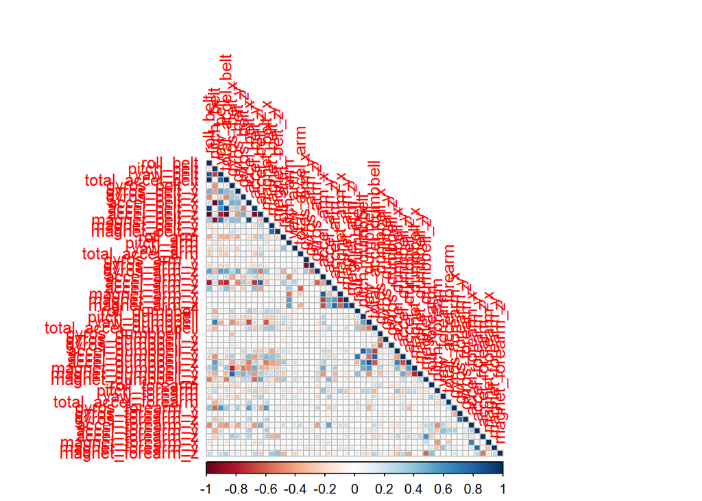

```r
corrplot::corrplot(descrCor, method="square", type="lower")
```

## Model Tuning Paramters

### Figure 2. Accuracy graph with tree levels

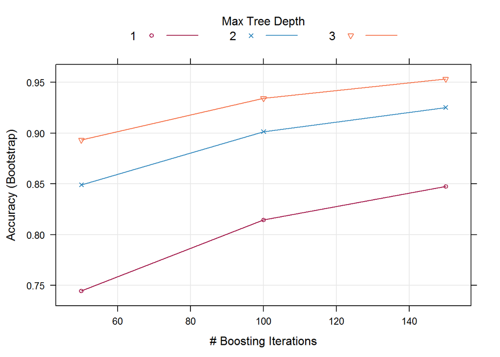

```r
gbm.model = readRDS("gbmModel.rds")
trellis.par.set(caretTheme())
plot(gbm.model)
```

### Figure 3. Heat Map, with kappa bootstrap iterations and tree levels

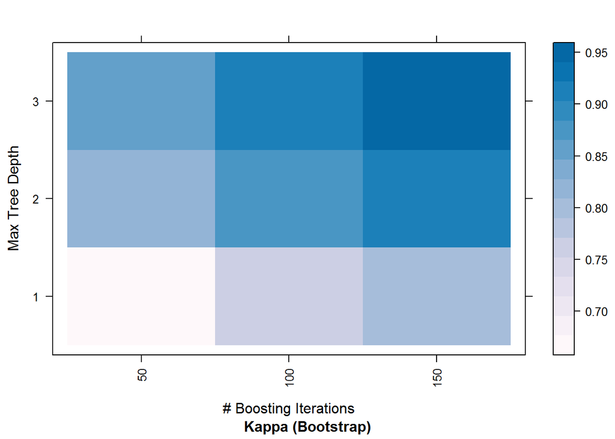

```r
trellis.par.set(caretTheme())
plot(gbm.model, metric = "Kappa", plotType = "level",
     scales = list(x = list(rot = 90)))
```